# Exploring relationships between variables

## 5.2 Nonmetric multidimensional scaling (NMDS)

PCA and many related techniques are based on linear algebra and eigenvalues. This is fine for datasets where variables are mostly linearly related to each other, or can be transformed to be linearly related. Most of the eigenvalue-based techniques also require data to be mostly normally distributed.

If relationships between variables are nonlinear, or if the many other assumptions of eigenvalue-based ordination cannot be met, then the next best option is a non-parametric ordination technique called nonmetric multidimensional scaling (NMDS or NMS). Unlike PCA, which solves linear algebra problems to extract synthetic gradients (“principal components”), NMDS works by trying iteratively to arrange the samples into a reduced dimensional space that preserves the rank order of the distance matrix.

What? Let’s break that down:

**Distance matrix:** a matrix containing a measure of dissimilarity (aka: “distance”) between each pair of samples. This is exactly analogous to a road mileage chart in an old paper road atlas.

**Distance (dissimilarity) measure:** a quantity that measures how different two samples are in terms of several variables. Greater values indicate that two samples are more different from each other; smaller values indicate that two samples are more similar to each other. See [this page](https://greenquanteco.github.io/08-multi-01-distance.html) for a more in-depth explanation of distance measures.

The most famous distance metric is the Euclidean distance metric, shown here as the distance between two points on the *XY* plane:

$$D_{Euc.}=\sqrt{\left(x_1-x_2\right)^2+\left(y_1-y_2\right)^2}$$

The metric can be generalized to any number of dimensions *k*.

$$D_{Euc.}=\sqrt{\sum_{k=1}^{k}\left(x_1-x_2\right)^2}$$

The Euclidean distance is rarely used for NMDS. Instead, the default distance metric is the **Bray-Curtis distance**. This metric is called **Sørensen distance** when used for binary values (e.g., presence-absence), and Bray-Curtis when used for quantitative values.

The distance matrix contains the dissimilarities between samples, in terms of all of the variables in the dataset. If there are *k* variables, then these are distances through *k*-dimensional space. NMDS tries to represent the relative dissimilarities between samples in fewer than *k* dimensions, while preserving the **rank order** of those dissimilarities.

The R function `metaMDS()` performs NMDS. Getting a biplot of the ordination is a little more involved than for PCA. Note that NMDS involves some random number sampling in its algorithms, so you should set the random number seed to make sure your analysis is reproducible.

```r
set.seed(123)

# fit NMDS
n1 <- metaMDS(x)
```

```
## Square root transformation
## Wisconsin double standardization
## *** Solution reached
```

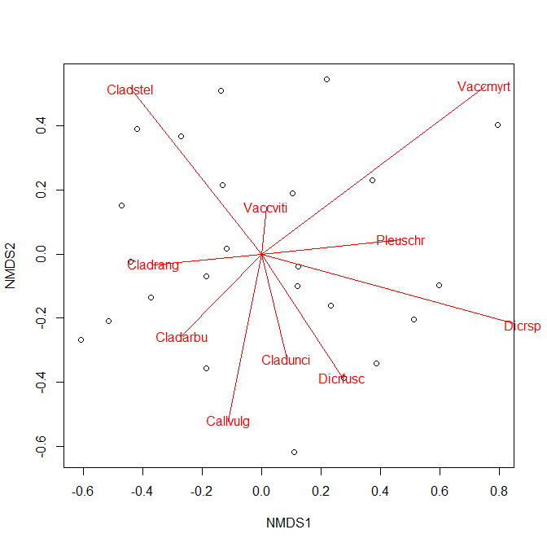

```r
# extract "scores" (coordinates in NMDS space)
# these are matrices: column 1 = x, column 2 = y
n1s <- scores(n1, "sites")
n1p <- scores(n1, "species")

# basic NMDS plot
plot(n1s)
# add biplot arrows and labels
segments(0, 0, n1p[,1], n1p[,2], col="red")
text(n1p[,1], n1p[,2], rownames(n1p), col="red", xpd=NA)
```

Because NMDS solutions are reached through random sampling, they are not guaranteed to reach a stable condition every time. You will need to set the random number seed to get reproducible results. There is also no guarantee that the solution reached by NMDS will be the optimal one.

Another consequence of the way that NMDS works is that the axes themselves are arbitrary, unlike the axes in PCA. This means that we can’t calculate a percentage of variation explained by each axis the way we did for PCA. By default, R will rotate NMDS solutions so that the greatest amount of variation is associated with axis 1, but there is no guarantee that this axis captures a meaningful biological gradient.

The most important diagnostic parameter in an NMDS is the **stress**, which is a measure of how much the distance matrix is distorted by compression into low dimensional space. Lower stress value indicate better fit. Most people consider a stress $\ge$ 0.2 to indicate an unreliable fit. Some authors recommend lower thresholds like 0.15 or 0.1. Package `vegan` and most sources use stress values <1 (e.g., Legendre and Legendre 2012); some authors scale stress by a factor of 100 relative to the values in `vegan`. For example, the program PC-ORD (McCune et al. 2002) uses stress values on this greater scale.

## 5.3 Plotting ordinations

Extracting the scores from an ordination object can let you plot points with all of the `base` graphics formatting tricks we learned above, such as using color or shape to indicate group membership. In my experience this is more flexible than using the built-in graphics capabilities in `vegan`[^4], but your mileage may vary.

```r
x <- crabs
p1 <- rda(x[,4:8])
n1 <- metaMDS(x[,4:8])
```

```
## Square root transformation
## Wisconsin double standardization
## *** Solution reached
```

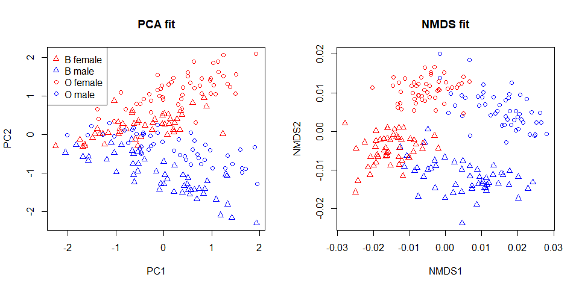

```r
p1s <- scores(p1)$sites
p1p <- scores(p1)$species

n1s <- scores(n1, "sites")
n1p <- scores(n1, "species")

cols1 <- ifelse(x$sex == "F", "red", "blue")
pch1 <- ifelse(x$sp == "B", 2, 1)

par(mfrow=c(1,2))
plot(p1s, col=cols1, pch=pch1, main="PCA fit")
legend("topleft",
       legend=c("B female", "B male", "O female", "O male"),
       pch=c(2, 2, 1, 1),
       col=c("red", "blue", "red", "blue"))
plot(n1s, col=cols1, pch=pch1, main="NMDS fit")
```

## 5.4 Ordination wrap-up (for now)

Ordination is a collection of methods for reducing the dimensionality of data. Biological datasets often have many variables, but most variation in those datasets can often be captured using only a few of them (or few combinations of the variables). The positions of the samples in the ordination space can thus reveal patterns that are too complicated to see in the full data space. Interpreting ordination axes in biological terms can be very fruitful. When an axis captures important information about the samples, it can be used as a variable in another method (e.g., as a predictor variable in a linear model). Analysis of clustering or positional differences between groups in ordination space (especially NMDS space) can allow for researchers to test for differences in many variables at once.

[**Go back to main page**](https://greenquanteco.github.io/index.html)

# 6 References

Bolker, B. M. 2008. Ecological models and data in R. Princeton University Press, Princeton, New Jersey, USA.

Legendre, P., and L. Legendre. 2012. Numerical ecology. Elsevier, Amsterdam.

McCune, B., J. B. Grace, and D. L. Urban. 2002. Analysis of ecological communities. MjM software design Gleneden Beach, Oregon, USA.

# 7 Legal notice

This site is for educational purposes only. This work and its content is released under the [Creative Commons Attribution-ShareAlike 4.0](https://creativecommons.org/licenses/by-sa/4.0/) license. Inclusion of third-party data falls under guidelines of fair use as defined in [section 107 of the US Copyright Act of 1976](https://www.law.cornell.edu/uscode/text/17/107).

[^1]: You can also specify colors by their RGB or hex codes. A graphical reference is [here](https://rstudio-pubs-static.s3.amazonaws.com/3486_79191ad32cf74955b4502b8530aad627.html) (accessed 2021-12-17). The [ColorBrewer](https://colorbrewer2.org/) website (accessed 2021-12-17) and R package can help picking appropriate color schemes.
[^2]: Locally estiamted sums of squares, a common smoothing curve algorithm.
[^3]: In the base R PCA functions, these values are obtained from the `rotation` part of the output in `prcomp()` or from the `loadings` component in `princomp()`.
[^4]: An introduction by the package’s lead author can be found here: https://cran.r-project.org/web/packages/vegan/vignettes/intro-vegan.pdf (accessed 2021-09-17)